# Churn Prediction - Comparing Multiple Models

#### Dependent - Independent Variables Relationship

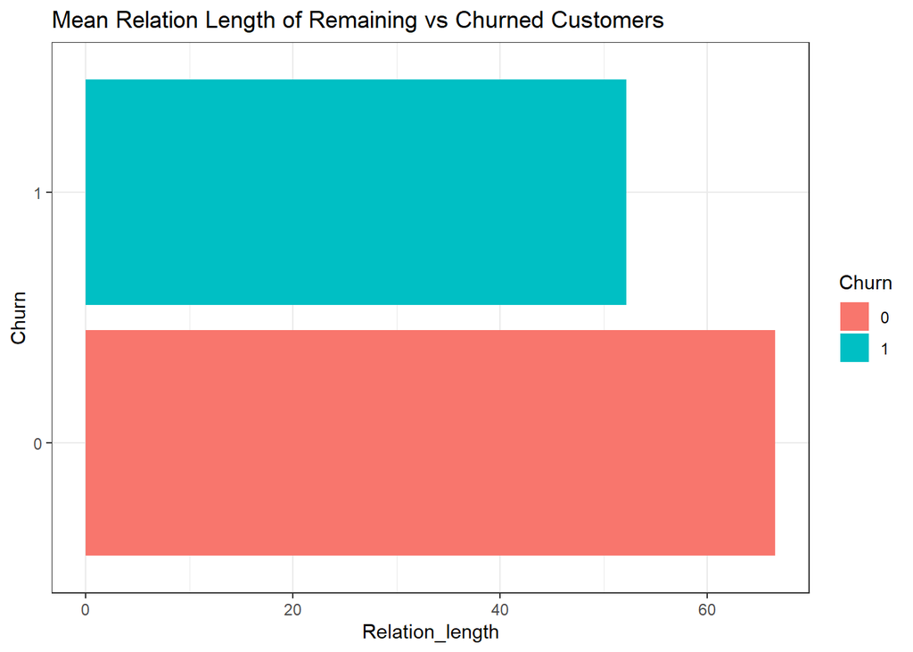

```r
## Discrete Variables
## Relation length (Significant)
ggplot(data, aes(x = Relation_length, y = Churn, fill = Churn)) +
  stat_summary(fun = "mean", geom = "col") +
  labs(title = "Mean Relation Length of Remaining vs Churned Customers") +
  theme_bw()
```

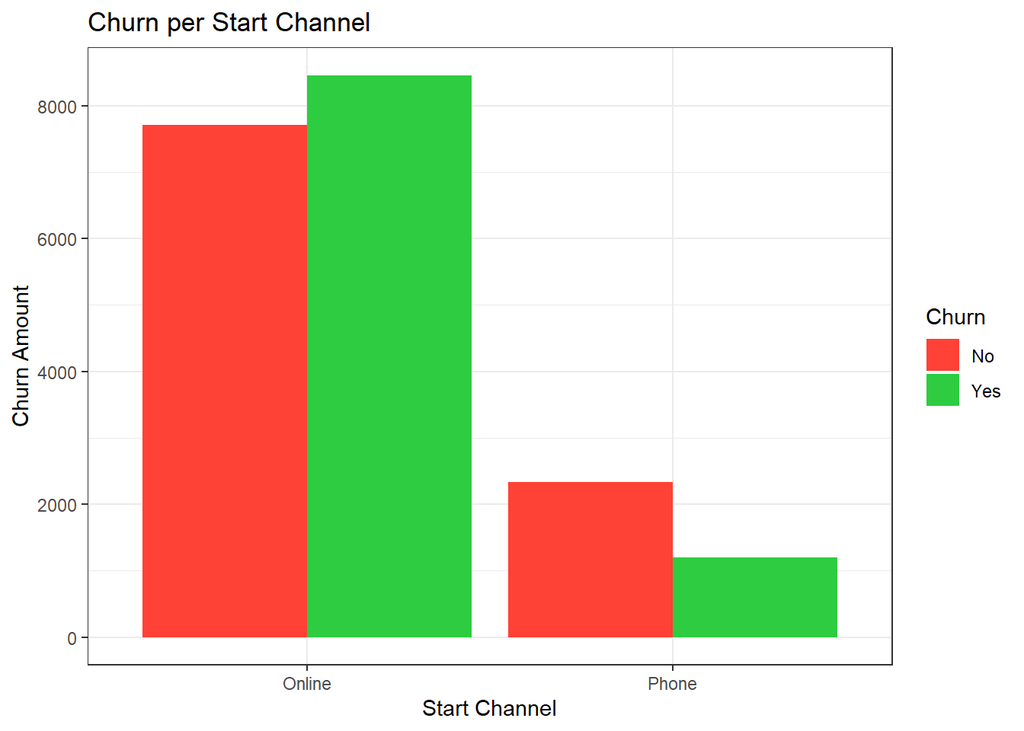

```r
## Start_channel (Significant)
ggplot(data, aes(x = Start_channel, fill = Churn)) +
  geom_bar(position = "dodge") +
  labs(x="Start Channel", y="Churn Amount", title="Churn per Start Channel") +
  scale_fill_manual(values=c("#FF4136", "#2ECC40"), labels=c("No", "Yes")) +
  theme_bw()
```

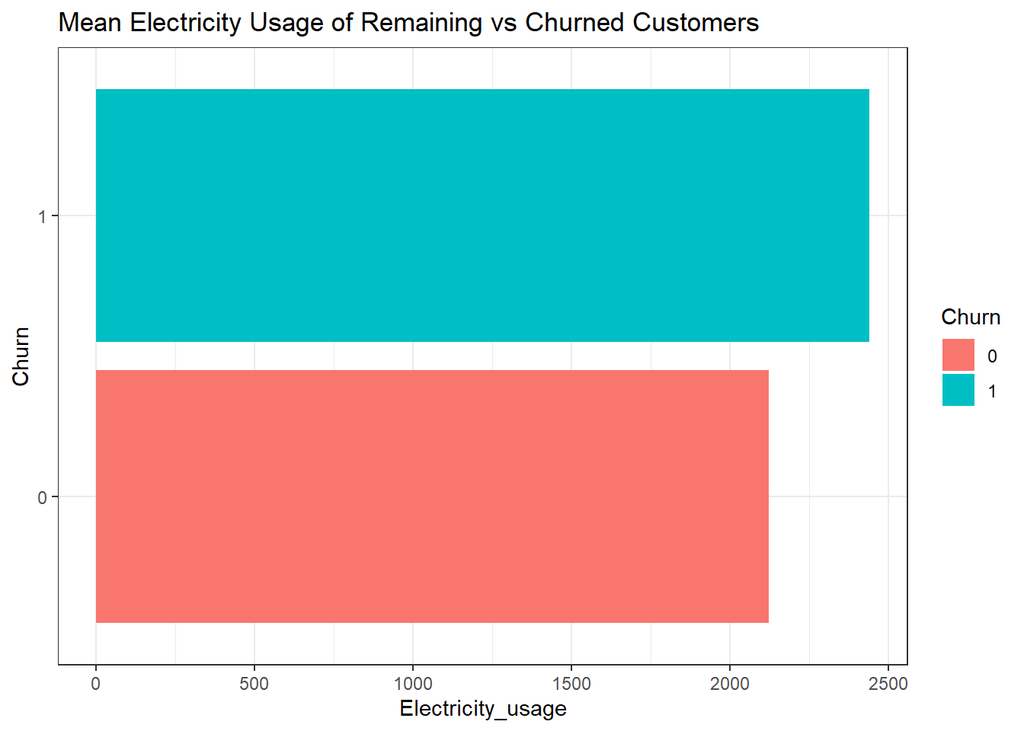

```r
## Electricity usage (Significant)
ggplot(data, aes(x = Electricity_usage, y = Churn, fill = Churn)) +
  stat_summary(fun = "mean", geom = "col") +
  labs(title = "Mean Electricity Usage of Remaining vs Churned Customers") +
  theme_bw()
```

The analysis of customer behavior reveals that a significant portion of high electricity and gas usage customers have experienced churn. Notably, customers with flexible contracts, indicative of shorter relationship lengths, show a higher likelihood of churning. Furthermore, the acquisition channels play a role in customer retention. The company has acquired a greater number of customers online compared to phone acquisitions. Interestingly, a higher percentage of customers acquired online have churned, while a larger proportion of customers acquired through phone interactions have remained loyal to the company.